# T7

### TCX3212 Predictive Analytics

### Tutorial/Lab 7

Learning Objectives

- Understand what a time series is and how to create it in Python.
- Visualize time series data and apply smoothing techniques
- Make simple forecasts using moving averages and naive models.
- Evaluate forecast accuracy using regression statistics

```python
# In JupyterLab, first navigate to the directory containing College.csv
# import os

# os.chdir("C:")  # Replace with your actual path
```

```python
# Set-up Python libraries - you need to run this but you don't need to change it
import pandas as pd
import matplotlib.pylab as plt
import statsmodels.formula.api as sm
from statsmodels.tsa import tsatools
```

#### Part 0: Understanding Time Series

Before analyzing the full Amtrak dataset, let’s start with a small example to understand a time series python object.

a) A python list has no dates. We need a DatetimeIndex to make it a time series.

- Data values = [112, 118, 132, 129, 121, 135, 148, 148, 136, 119].
- Start date: 01-01-2022
- Frequency: Month-End (ME) Use pd.date_range() to create dates, combine the data into a pd.Series and display the time-series object.

```python
import pandas as pd
import matplotlib.pyplot as plt

values = [112, 118, 132, 129, 121, 135, 148, 148, 136, 119]
dates = pd.date_range(start="2022-01-01", periods=10, freq="ME")

air_passengers = pd.Series(values, index=dates, name="Passengers")

print(air_passengers)
```

```
2022-01-31    112
2022-02-28    118
2022-03-31    132
2022-04-30    129
2022-05-31    121
2022-06-30    135
2022-07-31    148
2022-08-31    148
2022-09-30    136
2022-10-31    119
Freq: ME, Name: Passengers, dtype: int64
```

b)Extract data from March 2022 to October 2022. Plot the values with dates on the x-axis.

```
2022-03-31    132
2022-04-30    129
2022-05-31    121
2022-06-30    135
2022-07-31    148
2022-08-31    148
2022-09-30    136
2022-10-31    119
Freq: ME, Name: Passengers, dtype: int64
```

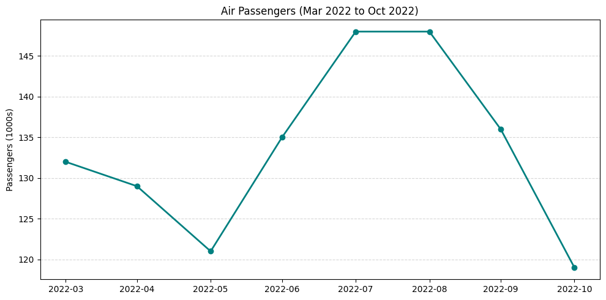

```python
import matplotlib.dates as mdates

mar_to_oct = air_passengers["2022-03":"2022-10"]

print(mar_to_oct)

fig, ax = plt.subplots(figsize=(10, 5))
ax.plot(mar_to_oct.index, mar_to_oct.values, marker="o", color="teal", linewidth="2")


ax.set_xticks(mar_to_oct.index)
# Format the x-axis to show dates nicely
ax.xaxis.set_major_formatter(mdates.DateFormatter("%Y-%m"))
plt.xticks(rotation=0)

ax.set_title("Air Passengers (Mar 2022 to Oct 2022)")
# ax.set_xlabel("Date")
ax.set_ylabel("Passengers (1000s)")
plt.grid(True, axis="y", linestyle="--", alpha=0.5)
plt.tight_layout()
plt.show()
```

### Time Series Analysis

In this exercise, you will explore and analyze monthly ridership data for Amtrak (January 1991 – March 2004). Learn to create time series objects, apply smoothing techniques, visualize trends, and make simple forecasts. You will be using the Amtrak (Amtrak.csv) data set which can be downloaded from Canvas. The dataset contains monthly ridership data from January 1991 to March 2004.

c) Load the Amtrak dataset. Construct a time-series object for the Amtrak ridership data from 01-01-1991 to 01-03-2004. Plot the monthly ridership with clearly labeled axes. What time series components appear from the plot?

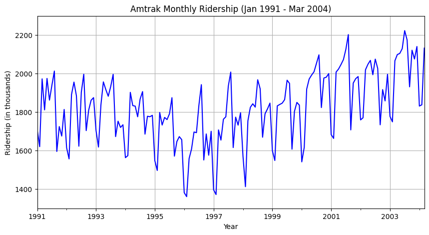

```python
# Load the Amtrak dataset
Amtrak_df = pd.read_csv("Amtrak.csv")

# Convert the Month column to datetime objects
# Amtrak_df["Month"] = pd.to_datetime(Amtrak_df["Month"], format="%d/%m/%Y")
clean_dates = pd.date_range(start="1991-01-01", periods=len(Amtrak_df), freq="MS")

# Create a time-series object (pandas Series with a DatetimeIndex)
ridership_ts = pd.Series(
    Amtrak_df["Ridership"].values, index=clean_dates, name="Ridership"
)

# Plot the monthly ridership
fig, ax = plt.subplots(figsize=(10, 5))
ridership_ts.plot(ax=ax, color="blue", linewidth=1.5)

ax.set_xlabel("Year")
ax.set_ylabel("Ridership (in thousands)")
ax.set_title("Amtrak Monthly Ridership (Jan 1991 - Mar 2004)")
ax.set_ylim(1300, 2300)
plt.grid(True)
plt.show()

# Observations on time series components:
# 1. Seasonality: There is a strong, repeating pattern every year (peaks in summer months and dips in winter months).
# 2. Trend: There is a longer-term, non-linear trend where ridership decreases until around 1996 and then starts to rise again.
```

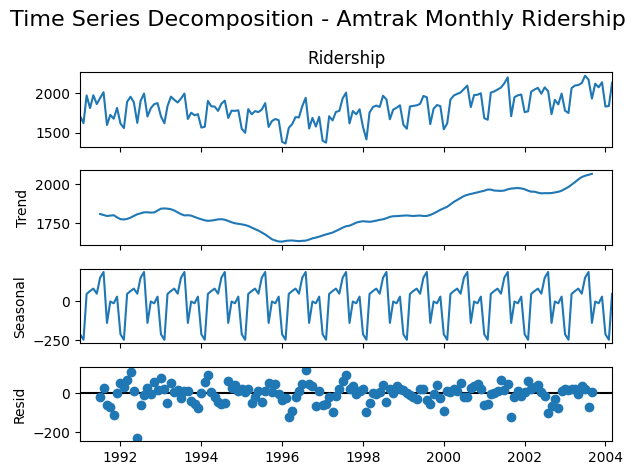

```python
from statsmodels.tsa.seasonal import seasonal_decompose

# Perform seasonal decomposition.
# We use an additive model because the amplitude of the seasonal variation
# does not appear to change strongly with the level of the trend.
decomposition = seasonal_decompose(ridership_ts, model="additive", period=12)

# Plot the decomposed components
fig = decomposition.plot()
fig.suptitle("Time Series Decomposition - Amtrak Monthly Ridership", fontsize=16)
plt.tight_layout()
plt.show()
```

d) Apply a 3rd-order and 12th-order centered moving averages, and plot the smoothed series overlaid on the original time series. Compare the results and explain how the window sizes affect smoothing.

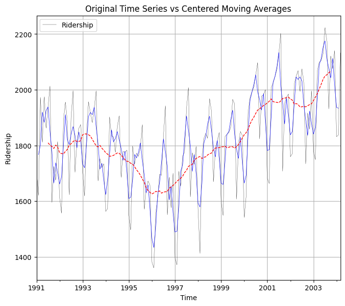

```python
# centered moving average with window size = 3 and 12
ma3 = ridership_ts.rolling(window=3, center=True).mean()
ma12 = ridership_ts.rolling(window=12, center=True).mean()

# Plot the original time series with the smoothed lines
fig, ax = plt.subplots(figsize=(8, 7))

ax = ridership_ts.plot(ax=ax, color="black", linewidth=0.25)
ma3.plot(ax=ax, color="blue", linewidth=0.5)
ma12.plot(ax=ax, color="red", linewidth=1, style="--")

ax.set_xlabel("Time")
ax.set_ylabel("Ridership")
ax.set_title("Original Time Series vs Centered Moving Averages")

ax.legend(["Ridership"])
plt.grid(True)
plt.show()
```

**Comparison and Effect of Window Size:**

- The **3-month MA** only lightly smooths the data but still follows the peaks and short-term fluctuations of ridership closely. It does not substantially remove the seasonality.
- The **12-month MA** smooths the data much more heavily, almost entirely removing the annual seasonal fluctuations (since the seasonal period length is 12) and revealing the underlying longer-term trend.
- **Conclusion**: A larger window size causes more smoothing by averaging over a wider period, acting as a stronger filter that cancels out short-term variation and noise to highlight macro trends. A smaller window length leaves more volatility and seasonality in the series.

e) Compute a 12th-order trailing moving average (center=False). Explain why a trailing moving average is suitable for forecasting.

```python
Amtrak_df["MA_12"] = Amtrak_df["Ridership"].rolling(window=12).mean()

with pd.option_context("display.max_rows", None, "display.max_columns", None):
    print(Amtrak_df["MA_12"])
```

```
0              NaN
1              NaN
2              NaN
3              NaN
4              NaN
5              NaN
6              NaN
7              NaN
8              NaN
9              NaN
10             NaN
11     1809.536500
12     1801.695667
13     1796.404167
14     1789.613167
```

[output cut: 145 more lines]

f) Using the last value of the 12-month trailing MA, create a naive forecast for the next 6 months (i.e., assume each future month equals the last available moving average). Present a table showing the original ridership, trailing MA, and forecasted values. Overlay the 12-month trailing moving average on the plot from part c.

```python
# Compute a 12-month trailing moving average to remove seasonal "noise."
Amtrak_df["MA_12"] = Amtrak_df["Ridership"].rolling(window=12).mean()

# Use naive model for 6-step-ahead forecast
# .iloc[-1] uses "Integer Location" start counting from the end [-1] is the last row in the dataset
last_ma = Amtrak_df["MA_12"].iloc[-1]  # last available MA

# We need the DatetimeIndex from earlier to correctly calculate the offset.
# The code in the picture relies on the DataFrame having a DatetimeIndex
Amtrak_df.index = pd.date_range(start="1991-01-01", periods=len(Amtrak_df), freq="MS")


# Generate 6 new months of dates, starting 1 month after the last date in our data.
# We create a new DataFrame for the future.
# 'Ridership' is None (unknown), but 'MA_12' is filled with our constant prediction (last_ma).
forecast_months = pd.date_range(
    start=Amtrak_df.index[-1] + pd.DateOffset(months=1), periods=6, freq="MS"
)
forecast_df = pd.DataFrame(
    {"Ridership": [None] * 6, "MA_12": [last_ma] * 6}, index=forecast_months
)

# Combine original data and forecast
full_df = pd.concat([Amtrak_df, forecast_df])

# Print the last 15 rows including forecast
# print(full_df.tail(20))

with pd.option_context("display.max_rows", None, "display.max_columns", None):
    print(full_df)
```

```
                 Month  Ridership        MA_12
1991-01-01  01/01/1991   1708.917          NaN
1991-02-01  01/02/1991   1620.586          NaN
1991-03-01  01/03/1991   1972.715          NaN
1991-04-01  01/04/1991   1811.665          NaN
1991-05-01  01/05/1991   1974.964          NaN
1991-06-01  01/06/1991   1862.356          NaN
1991-07-01  01/07/1991   1939.860          NaN
1991-08-01  01/08/1991   2013.264          NaN
1991-09-01  01/09/1991   1595.657          NaN
1991-10-01  01/10/1991   1724.924          NaN
1991-11-01  01/11/1991   1675.667          NaN
1991-12-01  01/12/1991   1813.863  1809.536500
1992-01-01  01/01/1992   1614.827  1801.695667
1992-02-01  01/02/1992   1557.088  1796.404167
1992-03-01  01/03/1992   1891.223  1789.613167
1992-04-01  01/04/1992   1955.981  1801.639500
1992-05-01  01/05/1992   1884.714  1794.118667
1992-06-01  01/06/1992   1623.042  1774.175833
1992-07-01  01/07/1992   1903.309  1771.129917
1992-08-01  01/08/1992   1996.712  1769.750583
1992-09-01  01/09/1992   1703.897  1778.770583
1992-10-01  01/10/1992   1810.000  1785.860250
1992-11-01  01/11/1992   1861.601  1801.354750
1992-12-01  01/12/1992   1875.122  1806.459667
1993-01-01  01/01/1993   1705.259  1813.995667
1993-02-01  01/02/1993   1618.535  1819.116250
1993-03-01  01/03/1993   1836.709  1814.573417
1993-04-01  01/04/1993   1957.043  1814.661917
1993-05-01  01/05/1993   1917.185  1817.367833
1993-06-01  01/06/1993   1882.398  1838.980833
1993-07-01  01/07/1993   1933.009  1841.455833
1993-08-01  01/08/1993   1996.167  1841.410417
1993-09-01  01/09/1993   1672.841  1838.822417
1993-10-01  01/10/1993   1752.827  1834.058000
1993-11-01  01/11/1993   1720.377  1822.289333
1993-12-01  01/12/1993   1734.292  1810.553500
1994-01-01  01/01/1994   1563.365  1798.729000
1994-02-01  01/02/1994   1573.959  1795.014333
1994-03-01  01/03/1994   1902.639  1800.508500
```

[output cut: 111 more lines]

```
2003-07-01  01/07/2003   2223.349  1973.583417
2003-08-01  01/08/2003   2174.360  1985.900083
2003-09-01  01/09/2003   1931.406  2002.337667
2003-10-01  01/10/2003   2121.470  2019.395917
2003-11-01  01/11/2003   2076.054  2037.538333
2003-12-01  01/12/2003   2140.677  2049.565417
2004-01-01  01/01/2004   1831.508  2054.021667
2004-02-01  01/02/2004   1838.006  2061.398083
2004-03-01  01/03/2004   2132.446  2066.896417
2004-04-01         NaN        NaN  2066.896417
2004-05-01         NaN        NaN  2066.896417
2004-06-01         NaN        NaN  2066.896417
2004-07-01         NaN        NaN  2066.896417
2004-08-01         NaN        NaN  2066.896417
2004-09-01         NaN        NaN  2066.896417
```

g) Partition the data by using the last 36 months as a validation set and the remaining observations as a training set. (Set nValid = 36)

```python
nValid = 36  # Last 36 months (3 years) for validation
nTrain = len(ridership_ts) - nValid  # the rest for training

train_ts = ridership_ts[:nTrain]  # training data
valid_ts = ridership_ts[nTrain:]  # validation data
```

h) The naive forecast is the simplest forecasting method in time series analysis. It assumes that the value of the series in the next time period will be equal to the last observed value in the training data. • Using the training time series, generate a naive forecast for the entire validation period. Each month in the validation set should be predicted using the last value from the training set.

```python
naive_pred = pd.Series(
    train_ts.iloc[-1], index=valid_ts.index
)  # Naive forecast: last observed value for all future points
print(naive_pred)
```

```
2001-04-01    2007.928
2001-05-01    2007.928
2001-06-01    2007.928
2001-07-01    2007.928
2001-08-01    2007.928
2001-09-01    2007.928
2001-10-01    2007.928
2001-11-01    2007.928
2001-12-01    2007.928
2002-01-01    2007.928
2002-02-01    2007.928
2002-03-01    2007.928
2002-04-01    2007.928
2002-05-01    2007.928
2002-06-01    2007.928
2002-07-01    2007.928
2002-08-01    2007.928
2002-09-01    2007.928
2002-10-01    2007.928
2002-11-01    2007.928
2002-12-01    2007.928
2003-01-01    2007.928
2003-02-01    2007.928
2003-03-01    2007.928
2003-04-01    2007.928
2003-05-01    2007.928
2003-06-01    2007.928
2003-07-01    2007.928
2003-08-01    2007.928
2003-09-01    2007.928
2003-10-01    2007.928
2003-11-01    2007.928
2003-12-01    2007.928
2004-01-01    2007.928
2004-02-01    2007.928
2004-03-01    2007.928
Freq: MS, dtype: float64
```

i) The seasonal naive forecast accounts for seasonality by assuming that future values repeat the same seasonal pattern observed in the most recent season. • Assume the data has a 12-month seasonal cycle. Generate a seasonal naive forecast for the validation period by repeating the last 12 months of the training data until the validation period is fully covered.. j)

```python
last_season = train_ts.iloc[-12:]
seasonal_pred = pd.Series(
    pd.concat([last_season] * 5)[: len(valid_ts)].values, index=valid_ts.index
)
print(seasonal_pred)
# Repeats the last observed seasonal cycle 5 times Jan, Feb, ....Dec,
```

```
2001-04-01    1971.493
2001-05-01    1992.301
2001-06-01    2009.763
2001-07-01    2053.996
2001-08-01    2097.471
2001-09-01    1823.706
2001-10-01    1976.997
2001-11-01    1981.408
2001-12-01    2000.153
2002-01-01    1683.148
2002-02-01    1663.404
2002-03-01    2007.928
2002-04-01    1971.493
2002-05-01    1992.301
2002-06-01    2009.763
2002-07-01    2053.996
2002-08-01    2097.471
2002-09-01    1823.706
2002-10-01    1976.997
2002-11-01    1981.408
2002-12-01    2000.153
2003-01-01    1683.148
2003-02-01    1663.404
2003-03-01    2007.928
2003-04-01    1971.493
2003-05-01    1992.301
2003-06-01    2009.763
2003-07-01    2053.996
2003-08-01    2097.471
2003-09-01    1823.706
2003-10-01    1976.997
2003-11-01    1981.408
2003-12-01    2000.153
2004-01-01    1683.148
2004-02-01    1663.404
2004-03-01    2007.928
Freq: MS, dtype: float64
```

j) Using the training and validation splits, plot the actual ridership together with the naive and seasonal naive forecasts on a single time-series chart.

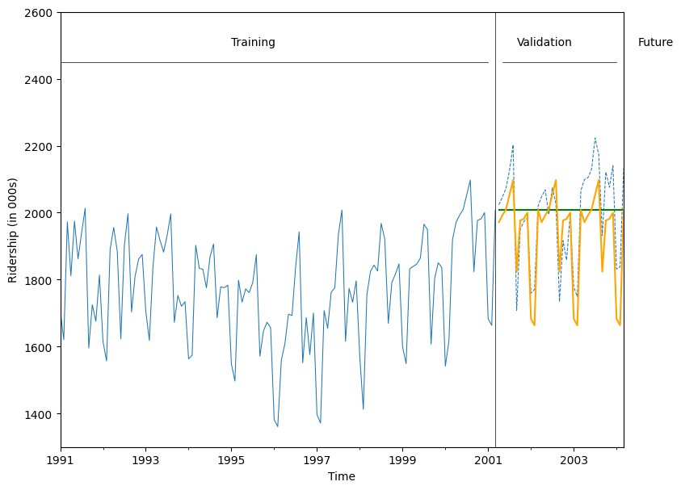

```python
# plot forecasts and actual in the training and validation sets
ax = train_ts.plot(color="C0", linewidth=0.75, figsize=(9, 7))
valid_ts.plot(ax=ax, color="C0", linestyle="dashed", linewidth=0.75)
ax.set_xlim("1990", "2006-6")
ax.set_ylim(1300, 2600)
ax.set_xlabel("Time")
ax.set_ylabel("Ridership (in 000s)")

naive_pred.plot(ax=ax, color="green")
seasonal_pred.plot(ax=ax, color="orange")

# determine coordinates for drawing the arrows and lines
one_month = pd.Timedelta("31 days")
xtrain = (min(train_ts.index), max(train_ts.index) - one_month)
xvalid = (min(valid_ts.index) + one_month, max(valid_ts.index) - one_month)
xfuture = (max(valid_ts.index) + one_month, "2006")

xtv = xtrain[1] + 0.5 * (xvalid[0] - xtrain[1])
xvf = xvalid[1] + 0.5 * (xfuture[0] - xvalid[1])
ax.add_line(plt.Line2D(xtrain, (2450, 2450), color="black", linewidth=0.5))
ax.add_line(plt.Line2D(xvalid, (2450, 2450), color="black", linewidth=0.5))
ax.add_line(plt.Line2D(xfuture, (2450, 2450), color="black", linewidth=0.5))
ax.text("1995", 2500, "Training")
ax.text("2001-9", 2500, "Validation")
ax.text("2004-7", 2500, "Future")
ax.axvline(x=xtv, ymin=0, ymax=1, color="black", linewidth=0.5)
ax.axvline(x=xvf, ymin=0, ymax=1, color="black", linewidth=0.5)
plt.show()
```

k) Implement a Python function regression_stats(actual, forecast) to evaluate forecast accuracy. The function should accept observed and forecasted time-series values as inputs and compute RMSE, MAE, MPE, and MAPE. Use this function to assess and compare different forecasting methods.

```python
import numpy as np
import pandas as pd


def regression_stats(actual, forecast):
    """
    Compute forecast accuracy statistics:
    ME, RMSE, MAE, MPE, MAPE
    """
    actual = np.array(actual)
    forecast = np.array(forecast)

    errors = actual - forecast

    ME = np.mean(errors)

    RMSE = np.sqrt(np.mean(errors**2))

    MAE = np.mean(np.abs(errors))

    MPE = np.mean(errors / actual) * 100

    MAPE = np.mean(np.abs(errors / actual)) * 100

    # print results
    print("Regression Statistics:")
    print(f"Mean Error (ME): {ME:.4f}")
    print(f"Root Mean Square Error (RMSE): {RMSE:.4f}")
    print(f"Mean Absolute Error (MAE): {MAE:.4f}")
    print(f"Mean Percentage Error (MPE): {MPE:.4f}%")
    print(f"Mean Absolute Percentage Error (MAPE): {MAPE:.4f}%")
    print("")


# Example usage with your forecasts
print("Naive Forecast Stats:")
regression_stats(valid_ts, naive_pred)

print("Seasonal Naive Forecast Stats:")
regression_stats(valid_ts, seasonal_pred)

print("12-Month Trailing Moving Average Forecast Stats:")
ma_12_valid = Amtrak_df["MA_12"][-nValid:]
regression_stats(valid_ts, ma_12_valid)
```

```
Naive Forecast Stats:
Regression Statistics:
Mean Error (ME): -14.7177
Root Mean Square Error (RMSE): 142.7551
Mean Absolute Error (MAE): 115.9234
Mean Percentage Error (MPE): -1.2750%
Mean Absolute Percentage Error (MAPE): 6.0214%

Seasonal Naive Forecast Stats:
Regression Statistics:
Mean Error (ME): 54.7296
Root Mean Square Error (RMSE): 95.6243
Mean Absolute Error (MAE): 84.0941
Mean Percentage Error (MPE): 2.6528%
Mean Absolute Percentage Error (MAPE): 4.2477%

12-Month Trailing Moving Average Forecast Stats:
Regression Statistics:
Mean Error (ME): 20.3960
Root Mean Square Error (RMSE): 142.5958
Mean Absolute Error (MAE): 123.1615
Mean Percentage Error (MPE): 0.5166%
Mean Absolute Percentage Error (MAPE): 6.2846%
```